# TeoNAM STAM — MLM (Family + K) GWAS with candidate genes + coverage sweep [118K panel]

The OLS model (Family + marker) plus a K random effect, on the authentic 118,838-SNP panel, and the five-caller coverage-degradation sweep under MLM

Author

Fausto Rodríguez-Zapata

Published

July 8, 2026

**What this is.** The MLM counterpart of `teonam-qtl-recovery-118k`: the same figures — JLM lollipop (Fig 4A), the authentic 118K GWAS Manhattan, the coverage-degradation composite, caller noisiness — but the GWAS model is a **mixed model** instead of OLS. The fixed structure is the **5-family factor** (the OLS/JLM structure), so this is literally “**OLS (`Family + marker`) + a K random effect**” and the OLS↔︎MLM contrast is the K term alone. In TeoNAM the structure *is* the five families, so this matches Chen’s Q = 5 PCs (Q ≈ Family; interchangeable — `scripts/teonam_mlm_family_118k.R`). Chen’s **exact** Fig-4C (TASSEL Q = 5 PCs + Centered_IBS K) and the QQ/λ_GC head-to-head are the sibling notebook `teonam-stam-mlm-gwas-118k`.

**ImportantKinship: full-data vs per-coverage**

- **Panels B & C** (authentic per-SNP and FSFHap ancestry-imputed) use K (VanRaden) estimated on the *full* panel — the single-experiment correction (R-EMMAX, `scripts/teonam_mlm_family_118k.R`, `teonam_mlm_fsfhap_118k.R`).
- **The coverage sweeps** keep the **Family** fixed term (known a priori, coverage- independent) but cannot use a full-panel K — at low coverage you only have shallow reads. So each coverage λ gets its **honest K homologue**: K (VanRaden) from the **GL dosage of the downsampled reads, *before* ancestry calling** (`scripts/teonam_mlm_null_bycov_118k.R`). K is caller-independent (one null per coverage), so only the *tested* recovered genotypes differ per caller. Per-marker test: `scripts/emmax_qk.R` (R-EMMAX, P3D, joint 2-df).

The central MLM result is a **confound, not a bug**: for the domestication traits K = teosinte-ancestry relatedness is nearly collinear with the QTL (a RIL is “teosinte-like” genome-wide *because* it carries teosinte alleles at *tb1* etc.), so the mixed model **absorbs the very signal it is meant to protect** — worst where K is best estimated (high coverage / full panel). This is why Chen used **JLM** (Fig 4A), not MLM, for the STAM QTL, and why the degradation sweep runs *backwards* under MLM.

```r
library(here)
library(data.table)
library(ggplot2)
library(fastman)
library(ggrepel)
library(ggtext)
library(scales)
library(cowplot)
```

```r
# Coordinate transformer replicating fastman_gg's internal x layout (shared verbatim
# with the OLS recovery notebook), so gene labels / lines land at arbitrary (chr, bp).
get_transformer <- function(m) {
  cmat <- do.call(rbind, lapply(
    split(m[order(m$CHR, m$BP), ], m$CHR[order(m$CHR, m$BP)]),
    function(d) {
      data.frame(
        CHR = d$CHR[1], min_bp = min(d$BP),
        width = max(d$BP) - min(d$BP),
        medgap = if (nrow(d) > 1) median(diff(sort(d$BP))) else 1
      )
    }
  ))
  cmat <- cmat[order(cmat$CHR), ]
  maxgap <- max(cmat$medgap, na.rm = TRUE)
  numc <- nrow(cmat)
  cmat$base <- 0
  cmat$midp <- 0
  cmat$midp[1] <- cmat$width[1] / 2
  for (i in 2:numc) {
    cmat$base[i] <- cmat$base[i - 1] + cmat$width[i - 1] + maxgap
    cmat$midp[i] <- cmat$base[i] + cmat$width[i] / 2
  }
  fac <- numc / cmat$midp[numc]
  cmat$basef <- fac * cmat$base
  function(chr, bp) {
    i <- match(chr, cmat$CHR)
    fac * (bp - cmat$min_bp[i]) + cmat$basef[i]
  }
}

LOD <- 5 # Chen 2019: P < 1e-5 (LOD = 5)

# genomic inflation factor: median(chi^2_obs) / median(chi^2_null), 1-df scale
lambda_gc <- function(p) {
  p <- p[is.finite(p) & p > 0 & p <= 1]
  round(median(qchisq(p, df = 1, lower.tail = FALSE)) / qchisq(0.5, df = 1), 3)
}

#' Read TASSEL MLM output (mlm_118k2.txt) into a scan (SNP, CHR, BP[v5], P) using the
#' joint 2-df additive+dominance p-value (column `p`), dropping the mean ("None") row.
read_mlm_tassel <- function(txt) {
  d <- fread(txt)
  d <- d[Marker != "None" & !is.na(Chr) & is.finite(p)]
  data.table(SNP = d$Marker, CHR = as.integer(d$Chr), BP = as.integer(d$Pos), P = as.numeric(d$p))
}

#' STAM Manhattan with candidate genes at their true v5 positions (shared with the OLS
#' notebook; accepts a data.frame scan so it works on the parsed TASSEL table).
plot_stam_manhattan <- function(scan_csv, title, out_png = NULL, mark = NULL) {
  scan <- if (is.data.frame(scan_csv)) as.data.frame(scan_csv) else as.data.frame(fread(scan_csv))
  scan <- scan[is.finite(scan$P) & scan$P > 0, ]
  m <- scan[order(scan$CHR, scan$BP), c("SNP", "CHR", "BP", "P")]

  ov <- fread(here("results/sim/teonam/stam_candidate_overlap.csv")) # symbol, chr, start (v5)
  ov[, y := vapply(seq_len(.N), function(i) {
    w <- m$P[m$CHR == chr[i] & abs(m$BP - start[i]) <= 5e5]
    if (length(w)) -log10(min(w)) else NA_real_
  }, numeric(1))]
  tr <- get_transformer(m)
  ov[, BPn := tr(chr, start)]
  ov <- ov[is.finite(y)]

  mp <- -log10(min(m$P))
  ticks <- pretty(c(0, mp))
  unit <- diff(ticks)[1]
  ytop <- max(ticks) + unit

  p <- fastman_gg(
    m = m, snp = "SNP", col = c("black", "gray75"), maxP = mp,
    genomewideline = NULL, suggestiveline = NULL,
    ylab = expression(-log[10](italic(P))), xlab = ""
  ) +
    geom_hline(yintercept = LOD, linetype = "dotted", linewidth = 0.7, color = "black") +
    geom_point(data = ov, aes(x = BPn, y = y), inherit.aes = FALSE, shape = 8, size = 3, stroke = 1, color = "red") +
    ggrepel::geom_text_repel(
      data = ov, aes(x = BPn, y = y, label = symbol), inherit.aes = FALSE,
      fontface = "italic", size = 5, segment.color = "grey50", min.segment.length = 0,
      box.padding = 0.5, max.overlaps = Inf, ylim = c(mp + 0.3 * unit, ytop)
    ) +
    ggtitle(title) +
    theme_classic(base_size = 18) +
    scale_y_continuous(breaks = ticks, limits = c(0, ytop), expand = expansion(mult = c(0.01, 0))) +
    theme(
      plot.title = element_markdown(hjust = 1, size = 15, face = "bold"),
      legend.position = "none",
      panel.grid.major.y = element_line(color = "grey90", linewidth = 0.2)
    )
  if (!is.null(mark)) {
    xm <- tr(mark$chr, mark$bp)
    p <- p + geom_vline(xintercept = xm, linetype = "dashed", color = "red", linewidth = 0.5)
  }
  if (!is.null(out_png)) ggsave(out_png, p, width = 9, height = 4.6, dpi = 200, bg = "white")
  p
}

#' Chen 2019 Fig 4A: JLM QTL genomic distribution as a lollipop (shared verbatim with
#' the OLS recovery notebook). JLM is a separate stepwise arm; identical in both.
plot_stam_lollipop <- function(jlm_txt, scan_csv, title, out_png = NULL) {
  scan <- if (is.data.frame(scan_csv)) as.data.frame(scan_csv) else as.data.frame(fread(scan_csv))
  scan <- scan[is.finite(scan$P) & scan$P > 0, ]
  maxis <- scan[order(scan$CHR, scan$BP), c("SNP", "CHR", "BP", "P")]

  j <- fread(jlm_txt)
  j <- j[!(Name %in% c("mean", "Family", "Error"))]
  q <- data.table(SNP = j$Name, CHR = as.integer(j$Locus), BP = as.integer(j$Position), logP = -log10(as.numeric(j$`pr>F`)))
  q <- q[logP >= LOD]
  ov <- fread(here("results/sim/teonam/stam_candidate_overlap.csv"))
  ov <- ov[symbol %in% c("ts2", "tb1", "tru1", "zmm16", "tsh4")]
  q[, gene := ""]
  for (i in seq_len(nrow(ov))) {
    idx <- which(q$CHR == ov$chr[i])
    if (length(idx)) {
      k <- idx[which.min(abs(q$BP[idx] - ov$start[i]))]
      q$gene[k] <- ov$symbol[i]
    }
  }
  tr <- get_transformer(maxis)
  q[, BPn := tr(CHR, BP)]
  maxlogP <- max(q$logP)
  brks <- seq(0, floor(maxlogP / 10) * 10, by = 10)
  ytop <- maxlogP * 1.18

  p <- fastman_gg(
    m = maxis, snp = "SNP", col = c("#00000000", "#00000000"), maxP = maxlogP,
    genomewideline = NULL, suggestiveline = NULL,
    ylab = expression(-log[10](italic(P))), xlab = ""
  ) +
    geom_segment(data = q, aes(x = BPn, xend = BPn, y = 0, yend = logP), inherit.aes = FALSE, color = "blue", linewidth = 0.5) +
    geom_point(data = q, aes(x = BPn, y = logP), inherit.aes = FALSE, color = "blue", size = 2.5) +
    ggrepel::geom_text_repel(
      data = q[gene != ""], aes(x = BPn, y = logP, label = gene), inherit.aes = FALSE,
      fontface = "bold.italic", size = 5, segment.color = NA, box.padding = 0.4,
      point.padding = 0.3, nudge_y = 0.05 * maxlogP, seed = 1, max.overlaps = Inf
    ) +
    ggtitle(title) + theme_classic(base_size = 18) +
    scale_y_continuous(breaks = brks, limits = c(0, ytop), expand = expansion(mult = c(0.01, 0))) +
    theme(
      plot.title = element_markdown(hjust = 1, size = 15, face = "bold"),
      legend.position = "none",
      panel.grid.major.y = element_line(color = "grey90", linewidth = 0.2)
    )
  if (!is.null(out_png)) ggsave(out_png, p, width = 9, height = 4, dpi = 200, bg = "white")
  p
}

#' Coverage-sweep line-Manhattan (geom_line, one line per coverage). Shared verbatim
#' with the OLS recovery notebook.
plot_sweep_line <- function(sweep_csv, title, legend = TRUE, base_size = 14) {
  sw <- as.data.table(fread(sweep_csv))
  sw <- sw[is.finite(P) & P > 0]
  sw[, logP := -log10(P)]
  tr <- get_transformer(as.data.frame(sw[coverage == sw$coverage[1], .(CHR, BP)]))
  sw[, BPn := tr(CHR, BP)]
  cov_levels <- c("∞", "20", "10", "5", "1", "0.5", "0.2", "0.1")
  sw[, cov_lab := factor(ifelse(is.finite(coverage), formatC(coverage), "∞"), levels = cov_levels)]
  cov_asc <- c("0.1", "0.2", "0.5", "1", "5", "10", "20")
  pal <- setNames(grDevices::hcl.colors(7, "viridis"), cov_asc)
  pal["∞"] <- "black"
  axis_df <- sw[, .(mid = (min(BPn) + max(BPn)) / 2), by = CHR][order(CHR)]
  ytop <- 20
  sw[, dord := ifelse(is.finite(coverage), -coverage, Inf)]

  # LOD-5 peak loci (above-threshold markers clumped within 1 Mb -> top marker per
  # clump): infinity = black up-triangles just below the axis (caller ceiling), 0.5x =
  # down-triangles in the 0.5x legend colour near the top. Matches
  # scripts/teonam_sweep_manhattan_png.R.
  peak_loci <- function(cvsub, gap = 1e6) {
    s <- cvsub[logP > LOD]
    if (!nrow(s)) return(s[0])
    setorder(s, CHR, BP)
    s[, pk := cumsum(CHR != shift(CHR, fill = -1L) | BP - shift(BP, fill = -1L) > gap)]
    s[, .SD[which.max(logP)], by = pk]
  }
  pk_inf <- peak_loci(sw[!is.finite(coverage)])
  pk_05 <- peak_loci(sw[coverage == 0.5])

  ggplot(sw[order(dord, CHR, BP)], aes(x = BPn, y = logP, color = cov_lab, group = interaction(CHR, coverage))) +
    geom_line(linewidth = 0.4) +
    geom_hline(yintercept = LOD, linetype = "dotted", linewidth = 0.7, color = "grey30") +
    geom_point(
      data = pk_inf, aes(x = BPn, y = -0.045 * ytop), inherit.aes = FALSE,
      shape = 24, fill = "black", colour = "black", size = 2.4
    ) + # infinity LOD-5 loci: black up-triangles BELOW the x-axis (shape 24 mirrors 25)
    geom_point(
      data = pk_05, aes(x = BPn, y = 0.98 * ytop), inherit.aes = FALSE,
      shape = 25, fill = pal[["0.5"]], colour = pal[["0.5"]], size = 2.4
    ) + # 0.5x LOD-5 loci: down-triangles in the 0.5x legend colour, at the top
    scale_color_manual(values = pal, name = "coverage (×)", drop = FALSE) +
    scale_x_continuous(breaks = axis_df$mid, labels = axis_df$CHR, expand = c(0.01, 0)) +
    scale_y_continuous(expand = expansion(mult = c(0.01, 0))) +
    coord_cartesian(ylim = c(0, ytop), clip = "off") + # allow the below-axis infinity triangles to render in the margin
    labs(x = "chromosome", y = expression(-log[10](italic(P))), title = title) +
    theme_classic(base_size = base_size) +
    theme(
      plot.margin = margin(t = 5, r = 6, b = 16, l = 6), # room below the axis for the infinity triangles
      plot.title = element_markdown(hjust = 0, size = base_size, face = "bold"),
      panel.grid.major.y = element_line(color = "grey90", linewidth = 0.2),
      legend.position = if (legend) c(0.995, 0.97) else "none",
      legend.justification = c(1, 1),
      legend.background = element_rect(fill = scales::alpha("white", 0.7), colour = NA),
      legend.key.size = unit(0.85, "lines"),
      legend.title = element_text(size = base_size - 3),
      legend.text = element_text(size = base_size - 4),
      legend.margin = margin(1, 3, 1, 3)
    ) +
    guides(color = guide_legend(override.aes = list(linewidth = 1.2)))
}

# Panel B = MLM (Family + K) on the authentic per-SNP panel (R-EMMAX; scripts/
# teonam_mlm_family_118k.R). Family (not 5 PCs) so B and C share the OLS structure and
# the OLS<->MLM contrast is the K term alone. The faithful TASSEL Q+K Fig-4C (Chen's
# exact model) is the sibling notebook teonam-stam-mlm-gwas-118k.html; read_mlm_tassel()
# below still parses it if needed.
mlm <- fread(here("data/teonam/stam_gwas_mlm_family_118k.csv"))
```

## Candidate genes: closest marker vs most-significant marker (v5)

For each STAM candidate gene (B73 v5), the **closest** marker (smallest bp distance to the gene body) vs the **window-max** marker (highest −log₁₀P within ±500 kb) in the authentic 118K **MLM (Family+K)** scan. As under OLS they are not the same marker: the closest marker sits on the gene but carries little signal; the local peak is a nearby but distinct marker.

```r
sc <- copy(mlm)[is.finite(P) & P > 0][, logP := -log10(P)]
cand <- c(ts2 = "STAM1.1", tb1 = "STAM1.2", tru1 = "STAM3.1", zmm16 = "STAM3.2", tsh4 = "STAM7.1", an1 = "GWAS(chr1)")
sym <- fread(here("data/ref/maize_v5_gene_symbols.tsv"))
setnames(sym, c("gene_id", "symbol"))
coord <- fread(here("data/ref/b73_gene_coords.tsv"), header = FALSE, col.names = c("gene_id", "chr", "start", "end"))
gg <- merge(sym[symbol %in% names(cand)], coord, by = "gene_id")
gg[, chr := as.integer(sub("^chr", "", chr))][, qtl := cand[symbol]]
WIN <- 5e5
ctab <- rbindlist(lapply(seq_len(nrow(gg)), function(i) {
  ch <- gg$chr[i]; s <- gg$start[i]; e <- gg$end[i]
  m <- sc[CHR == ch]
  d <- pmax(0L, pmax(s - m$BP, m$BP - e))
  kc <- which.min(d)
  w <- m[BP >= s - WIN & BP <= e + WIN]
  kw <- which.max(w$logP)
  data.table(
    gene = gg$symbol[i], QTL = gg$qtl[i], chr = ch, `gene start (v5)` = s,
    `closest Δstart (bp)` = m$BP[kc] - s, `closest -log10P` = round(m$logP[kc], 2),
    `window-max Δstart (bp)` = w$BP[kw] - s, `window-max -log10P` = round(w$logP[kw], 2)
  )
}))
setorder(ctab, chr, `gene start (v5)`)
knitr::kable(ctab, format.args = list(big.mark = ","), caption = paste(
  "STAM candidate genes (B73 v5): CLOSEST marker vs highest -log10P marker within +/-500 kb",
  "(authentic 118K MLM Family+K scan). Δstart = marker bp - gene start (v5), signed."
))
```

STAM candidate genes (B73 v5): CLOSEST marker vs highest -log10P marker within +/-500 kb (authentic 118K MLM Family+K scan). Δstart = marker bp - gene start (v5), signed.

| gene | QTL | chr | gene start (v5) | closest Δstart (bp) | closest -log10P | window-max Δstart (bp) | window-max -log10P |
| --- | --- | --- | --- | --- | --- | --- | --- |
| ts2 | STAM1.1 | 1 | 46,511,946 | 1,592 | 0.30 | -269,615 | 3.84 |
| an1 | GWAS(chr1) | 1 | 246,895,757 | 656 | 1.65 | -368,239 | 4.42 |
| tb1 | STAM1.2 | 1 | 272,330,564 | -92,455 | 0.67 | -263,817 | 8.43 |
| tru1 | STAM3.1 | 3 | 152,086,191 | 420 | 1.27 | 149,536 | 5.23 |
| zmm16 | STAM3.2 | 3 | 176,074,772 | 1,564 | 4.27 | 6,112 | 6.95 |
| tsh4 | STAM7.1 | 7 | 138,540,580 | 372 | 3.31 | -32,266 | 5.18 |

## JLM QTL genomic distribution (Fig 4A)

The STAM QTL from JLM (TASSEL stepwise, nested-in-family), candidate genes bold-italic above their nearest QTL. **This arm is model-independent** — JLM, not MLM — so the lollipop is identical to the OLS notebook; it is Chen’s *primary* STAM analysis and the correct home for these domestication QTL (see the MLM confound below).

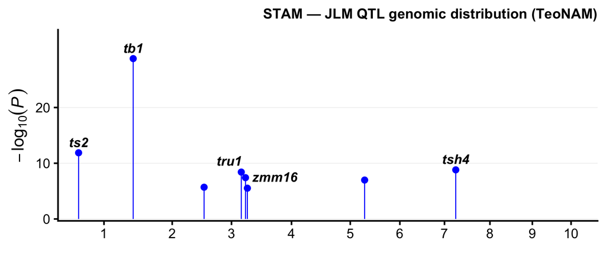

```r
p_lolli <- plot_stam_lollipop(
  here("data/teonam/tassel/stam_jlm_native1.txt"),
  mlm,
  "STAM — JLM QTL genomic distribution (TeoNAM)",
  here("results/sim/teonam/stam_jlm_lollipop_mlm118k.png")
)
p_lolli
```